# Part II - Ford GoBike System Analysis

## by Oluwatobi Ajao

## Investigation Overview

The dataset includes a February 2019 information about individual rides made in a bike-sharing system covering the greater San Francisco Bay area. Details such as the total duration of each subscriber's (or customer's) trip is located alongside the location where the trip started and where the trip ended. I have the aim of knowing the demographics of the bike riders; their age group and gender. I would also ike to the time of the day they mostly make rides and how long the riders by their age, gender, subscription status and hour of the day.

## Dataset Overview

The dataset has 183215 bike trips and 19 fields describing each field. The trips that span over 36 thousand hours were done in 329 stations. The columns are mostly float and string, except the duration_sec which is understandably integer

## Gender Distribution of the dataset

Plotting the Gender, Male vs Female to show which gender has the majority of the customers/subscribers

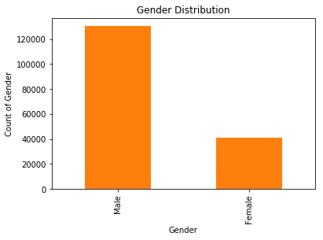

## Age distribution of riders

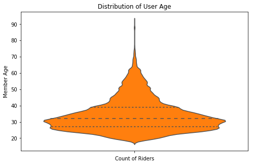

## Trips by Weekend vs Weekday hours

The analysis shows that as expected, riders make rides during weekends between morning and afternoon, with peak hours at mid-day. This is contrary to weekdays that have two peak periods; morning (between 7am and 9am) and evening (between 4pm and 7pm).

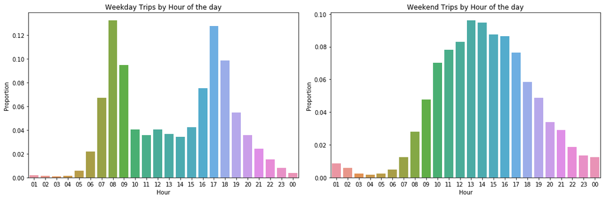

## Relationship between the duration, user types, and the gender of the Riders

We are going to look at how these three variables relate to each other using a violin plot.

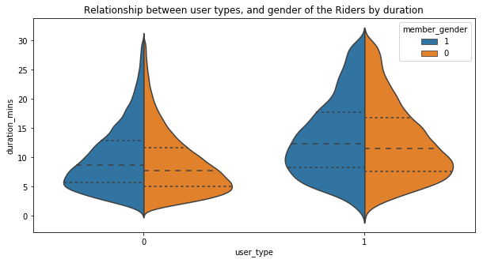